# SNP pipeline analysis of subjects with 3 body site results

```r
library(tidyverse)
source("MAP_functions.R")
```

### Subject 26

```r
SNP_analysis_pipeline(subject_id = 26)
```

```
[1] "SUBJECT_ID is 26"
```

```
[1] "Rare iSNP cutoff =  3"
[1] "num rare iSNPs =  3818"
[1] "num common iSNPs =  4876"
[1] "Recombination block cutoff = 3"
[1] "Num bases in C recomb blocks=  24514"
[1] "Num bases in R recomb = blocks 24514"
[1] "Num bases in V recomb = blocks 3567"
[1] "Coverage cutoff =  10"
[1] "Numbers of R bases above cutoff is  1039193"
[1] "Numbers of C bases above cutoff is  1039793"
[1] "Numbers of V bases above cutoff is  1037157"
[1] "Number of iSNP positions =  5768"
[1] "R only fixed SNPs (RonlyF) =  0"
[1] "R only rare fixed SNPs (RonlyFrare) =  0"
[1] "R only fixed SNPs in recombinant regions (RonlyFrecomb) =  0"
```

[output cut: 51 more lines]

### Subject 32

```r
SNP_analysis_pipeline(subject_id = 32)
```

```
[1] "SUBJECT_ID is 32"
[1] "Rare iSNP cutoff =  3"
[1] "num rare iSNPs =  3818"
[1] "num common iSNPs =  4876"
[1] "Recombination block cutoff = 3"
[1] "Num bases in C recomb blocks=  1680"
[1] "Num bases in R recomb = blocks 1500"
[1] "Num bases in V recomb = blocks 82373"
[1] "Coverage cutoff =  10"
[1] "Numbers of R bases above cutoff is  1039390"
[1] "Numbers of C bases above cutoff is  946335"
[1] "Numbers of V bases above cutoff is  1040321"
[1] "Number of iSNP positions =  5888"
[1] "R only fixed SNPs (RonlyF) =  0"
[1] "R only rare fixed SNPs (RonlyFrare) =  0"
```

[output cut: 52 more lines]

### Subject 68

```r
SNP_analysis_pipeline(subject_id = 68)
```

```
[1] "SUBJECT_ID is 68"
[1] "Rare iSNP cutoff =  3"
[1] "num rare iSNPs =  3818"
[1] "num common iSNPs =  4876"
[1] "Recombination block cutoff = 3"
[1] "Num bases in C recomb blocks=  66"
[1] "Num bases in R recomb = blocks 206"
[1] "Num bases in V recomb = blocks 0"
[1] "Coverage cutoff =  10"
[1] "Numbers of R bases above cutoff is  1034632"
[1] "Numbers of C bases above cutoff is  1038642"
[1] "Numbers of V bases above cutoff is  1035568"
[1] "Number of iSNP positions =  5628"
[1] "R only fixed SNPs (RonlyF) =  0"
[1] "R only rare fixed SNPs (RonlyFrare) =  0"
```

[output cut: 52 more lines]

### Subject 72

```r
SNP_analysis_pipeline(subject_id = 72)
```

```
[1] "SUBJECT_ID is 72"
[1] "Rare iSNP cutoff =  3"
[1] "num rare iSNPs =  3818"
[1] "num common iSNPs =  4876"
[1] "Recombination block cutoff = 3"
[1] "Num bases in C recomb blocks=  73594"
[1] "Num bases in R recomb = blocks 72610"
[1] "Num bases in V recomb = blocks 44984"
[1] "Coverage cutoff =  10"
[1] "Numbers of R bases above cutoff is  344700"
[1] "Numbers of C bases above cutoff is  1041370"
[1] "Numbers of V bases above cutoff is  1030153"
[1] "Number of iSNP positions =  751"
[1] "R only fixed SNPs (RonlyF) =  0"
[1] "R only rare fixed SNPs (RonlyFrare) =  0"
```

[output cut: 52 more lines]

### Subject 87

```r
SNP_analysis_pipeline(subject_id = 87)
```

```
[1] "SUBJECT_ID is 87"
[1] "Rare iSNP cutoff =  3"
[1] "num rare iSNPs =  3818"
[1] "num common iSNPs =  4876"
[1] "Recombination block cutoff = 3"
[1] "Num bases in C recomb blocks=  0"
[1] "Num bases in R recomb = blocks 0"
[1] "Num bases in V recomb = blocks 0"
[1] "Coverage cutoff =  10"
[1] "Numbers of R bases above cutoff is  1016776"
[1] "Numbers of C bases above cutoff is  1040034"
[1] "Numbers of V bases above cutoff is  1025941"
[1] "Number of iSNP positions =  1583"
[1] "R only fixed SNPs (RonlyF) =  0"
[1] "R only rare fixed SNPs (RonlyFrare) =  0"
```

[output cut: 52 more lines]

### Subject 98

```r
SNP_analysis_pipeline(subject_id = 98)
```

```
[1] "SUBJECT_ID is 98"
[1] "Rare iSNP cutoff =  3"
[1] "num rare iSNPs =  3818"
[1] "num common iSNPs =  4876"
[1] "Recombination block cutoff = 3"
[1] "Num bases in C recomb blocks=  0"
[1] "Num bases in R recomb = blocks 0"
[1] "Num bases in V recomb = blocks 0"
[1] "Coverage cutoff =  10"
[1] "Numbers of R bases above cutoff is  1041497"
[1] "Numbers of C bases above cutoff is  1041469"
[1] "Numbers of V bases above cutoff is  1036601"
[1] "Number of iSNP positions =  1569"
[1] "R only fixed SNPs (RonlyF) =  0"
[1] "R only rare fixed SNPs (RonlyFrare) =  0"
```

[output cut: 52 more lines]

### Subject 107

```r
SNP_analysis_pipeline(subject_id = 107)
```

```
[1] "SUBJECT_ID is 107"
[1] "Rare iSNP cutoff =  3"
[1] "num rare iSNPs =  3818"
[1] "num common iSNPs =  4876"
[1] "Recombination block cutoff = 3"
[1] "Num bases in C recomb blocks=  951"
[1] "Num bases in R recomb = blocks 951"
[1] "Num bases in V recomb = blocks 0"
[1] "Coverage cutoff =  10"
[1] "Numbers of R bases above cutoff is  1039211"
[1] "Numbers of C bases above cutoff is  794999"
[1] "Numbers of V bases above cutoff is  1030679"
[1] "Number of iSNP positions =  4193"
[1] "R only fixed SNPs (RonlyF) =  2"
[1] "R only rare fixed SNPs (RonlyFrare) =  2"
```

[output cut: 52 more lines]

### Subject 192

```r
SNP_analysis_pipeline(subject_id = 192)
```

```
[1] "SUBJECT_ID is 192"
[1] "Rare iSNP cutoff =  3"
[1] "num rare iSNPs =  3818"
[1] "num common iSNPs =  4876"
[1] "Recombination block cutoff = 3"
[1] "Num bases in C recomb blocks=  47748"
[1] "Num bases in R recomb = blocks 47523"
[1] "Num bases in V recomb = blocks 47523"
[1] "Coverage cutoff =  10"
[1] "Numbers of R bases above cutoff is  1040101"
[1] "Numbers of C bases above cutoff is  1039603"
[1] "Numbers of V bases above cutoff is  1038696"
[1] "Number of iSNP positions =  5786"
[1] "R only fixed SNPs (RonlyF) =  2"
[1] "R only rare fixed SNPs (RonlyFrare) =  2"
```

[output cut: 52 more lines]

### Subject 227

```r
SNP_analysis_pipeline(subject_id = 227)
```

```
[1] "SUBJECT_ID is 227"
[1] "Rare iSNP cutoff =  3"
[1] "num rare iSNPs =  3818"
[1] "num common iSNPs =  4876"
[1] "Recombination block cutoff = 3"
[1] "Num bases in C recomb blocks=  16439"
[1] "Num bases in R recomb = blocks 14887"
[1] "Num bases in V recomb = blocks 14887"
[1] "Coverage cutoff =  10"
[1] "Numbers of R bases above cutoff is  822798"
[1] "Numbers of C bases above cutoff is  1041331"
[1] "Numbers of V bases above cutoff is  1039947"
[1] "Number of iSNP positions =  1162"
[1] "R only fixed SNPs (RonlyF) =  0"
[1] "R only rare fixed SNPs (RonlyFrare) =  0"
```

[output cut: 52 more lines]

### Subject 362

```r
SNP_analysis_pipeline(subject_id = 362)
```

```
[1] "SUBJECT_ID is 362"
[1] "Rare iSNP cutoff =  3"
[1] "num rare iSNPs =  3818"
[1] "num common iSNPs =  4876"
[1] "Recombination block cutoff = 3"
[1] "Num bases in C recomb blocks=  168863"
[1] "Num bases in R recomb = blocks 168863"
[1] "Num bases in V recomb = blocks 168755"
[1] "Coverage cutoff =  10"
[1] "Numbers of R bases above cutoff is  1035844"
[1] "Numbers of C bases above cutoff is  1039225"
[1] "Numbers of V bases above cutoff is  1039676"
[1] "Number of iSNP positions =  2549"
[1] "R only fixed SNPs (RonlyF) =  0"
[1] "R only rare fixed SNPs (RonlyFrare) =  0"
```

[output cut: 52 more lines]

### Subject 519

```r
SNP_analysis_pipeline(subject_id = 519)
```

```
[1] "SUBJECT_ID is 519"
[1] "Rare iSNP cutoff =  3"
[1] "num rare iSNPs =  3818"
[1] "num common iSNPs =  4876"
[1] "Recombination block cutoff = 3"
[1] "Num bases in C recomb blocks=  395"
[1] "Num bases in R recomb = blocks 0"
[1] "Num bases in V recomb = blocks 226"
[1] "Coverage cutoff =  10"
[1] "Numbers of R bases above cutoff is  819909"
[1] "Numbers of C bases above cutoff is  1040846"
[1] "Numbers of V bases above cutoff is  1037480"
[1] "Number of iSNP positions =  4710"
[1] "R only fixed SNPs (RonlyF) =  0"
[1] "R only rare fixed SNPs (RonlyFrare) =  0"
```

[output cut: 52 more lines]

### Subject 564

```r
SNP_analysis_pipeline(subject_id = 564)
```

```
[1] "SUBJECT_ID is 564"
[1] "Rare iSNP cutoff =  3"
[1] "num rare iSNPs =  3818"
[1] "num common iSNPs =  4876"
[1] "Recombination block cutoff = 3"
[1] "Num bases in C recomb blocks=  0"
[1] "Num bases in R recomb = blocks 23231"
[1] "Num bases in V recomb = blocks 23231"
[1] "Coverage cutoff =  10"
[1] "Numbers of R bases above cutoff is  1036488"
[1] "Numbers of C bases above cutoff is  1039241"
[1] "Numbers of V bases above cutoff is  1014542"
[1] "Number of iSNP positions =  5762"
[1] "R only fixed SNPs (RonlyF) =  0"
[1] "R only rare fixed SNPs (RonlyFrare) =  0"
```

[output cut: 52 more lines]

### Subject 753

```r
SNP_analysis_pipeline(subject_id = 753)
```

```
[1] "SUBJECT_ID is 753"
[1] "Rare iSNP cutoff =  3"
[1] "num rare iSNPs =  3818"
[1] "num common iSNPs =  4876"
[1] "Recombination block cutoff = 3"
[1] "Num bases in C recomb blocks=  0"
[1] "Num bases in R recomb = blocks 0"
[1] "Num bases in V recomb = blocks 0"
[1] "Coverage cutoff =  10"
[1] "Numbers of R bases above cutoff is  620345"
[1] "Numbers of C bases above cutoff is  1038798"
[1] "Numbers of V bases above cutoff is  1039514"
[1] "Number of iSNP positions =  1102"
[1] "R only fixed SNPs (RonlyF) =  0"
[1] "R only rare fixed SNPs (RonlyFrare) =  0"
```

[output cut: 52 more lines]

### Subject 908

```r
SNP_analysis_pipeline(subject_id = 908)
```

```
[1] "SUBJECT_ID is 908"
[1] "Rare iSNP cutoff =  3"
[1] "num rare iSNPs =  3818"
[1] "num common iSNPs =  4876"
[1] "Recombination block cutoff = 3"
[1] "Num bases in C recomb blocks=  1485"
[1] "Num bases in R recomb = blocks 1691"
[1] "Num bases in V recomb = blocks 1485"
[1] "Coverage cutoff =  10"
[1] "Numbers of R bases above cutoff is  1037835"
[1] "Numbers of C bases above cutoff is  1034360"
[1] "Numbers of V bases above cutoff is  1007475"
[1] "Number of iSNP positions =  5676"
[1] "R only fixed SNPs (RonlyF) =  0"
[1] "R only rare fixed SNPs (RonlyFrare) =  0"
```

[output cut: 52 more lines]

### Subject 927

```r
SNP_analysis_pipeline(subject_id = 927)
```

```
[1] "SUBJECT_ID is 927"
[1] "Rare iSNP cutoff =  3"
[1] "num rare iSNPs =  3818"
[1] "num common iSNPs =  4876"
[1] "Recombination block cutoff = 3"
[1] "Num bases in C recomb blocks=  27215"
[1] "Num bases in R recomb = blocks 27215"
[1] "Num bases in V recomb = blocks 8664"
[1] "Coverage cutoff =  10"
[1] "Numbers of R bases above cutoff is  1040734"
[1] "Numbers of C bases above cutoff is  1040247"
[1] "Numbers of V bases above cutoff is  1040215"
[1] "Number of iSNP positions =  5876"
[1] "R only fixed SNPs (RonlyF) =  0"
[1] "R only rare fixed SNPs (RonlyFrare) =  0"
```

[output cut: 52 more lines]

### Subject 951

```r
SNP_analysis_pipeline(subject_id = 951)
```

```
[1] "SUBJECT_ID is 951"
[1] "Rare iSNP cutoff =  3"
[1] "num rare iSNPs =  3818"
[1] "num common iSNPs =  4876"
[1] "Recombination block cutoff = 3"
[1] "Num bases in C recomb blocks=  13256"
[1] "Num bases in R recomb = blocks 16904"
[1] "Num bases in V recomb = blocks 13256"
[1] "Coverage cutoff =  10"
[1] "Numbers of R bases above cutoff is  1040363"
[1] "Numbers of C bases above cutoff is  1039367"
[1] "Numbers of V bases above cutoff is  1038495"
[1] "Number of iSNP positions =  5834"
[1] "R only fixed SNPs (RonlyF) =  0"
[1] "R only rare fixed SNPs (RonlyFrare) =  0"
```

[output cut: 52 more lines]

### Subject 968

```r
SNP_analysis_pipeline(subject_id = 968)
```

```
[1] "SUBJECT_ID is 968"
[1] "Rare iSNP cutoff =  3"
[1] "num rare iSNPs =  3818"
[1] "num common iSNPs =  4876"
[1] "Recombination block cutoff = 3"
[1] "Num bases in C recomb blocks=  0"
[1] "Num bases in R recomb = blocks 0"
[1] "Num bases in V recomb = blocks 0"
[1] "Coverage cutoff =  10"
[1] "Numbers of R bases above cutoff is  578878"
[1] "Numbers of C bases above cutoff is  1041593"
[1] "Numbers of V bases above cutoff is  1040312"
[1] "Number of iSNP positions =  1434"
[1] "R only fixed SNPs (RonlyF) =  0"
[1] "R only rare fixed SNPs (RonlyFrare) =  0"
```

[output cut: 52 more lines]

### Subject 1077

```r
SNP_analysis_pipeline(subject_id = 1077)
```

```
[1] "SUBJECT_ID is 1077"
[1] "Rare iSNP cutoff =  3"
[1] "num rare iSNPs =  3818"
[1] "num common iSNPs =  4876"
[1] "Recombination block cutoff = 3"
[1] "Num bases in C recomb blocks=  15083"
[1] "Num bases in R recomb = blocks 14177"
[1] "Num bases in V recomb = blocks 14758"
[1] "Coverage cutoff =  10"
[1] "Numbers of R bases above cutoff is  799453"
[1] "Numbers of C bases above cutoff is  1038981"
[1] "Numbers of V bases above cutoff is  979648"
[1] "Number of iSNP positions =  4252"
[1] "R only fixed SNPs (RonlyF) =  0"
[1] "R only rare fixed SNPs (RonlyFrare) =  0"
```

[output cut: 52 more lines]

### Subject 1078

```r
SNP_analysis_pipeline(subject_id = 1078)
```

```
[1] "SUBJECT_ID is 1078"
[1] "Rare iSNP cutoff =  3"
[1] "num rare iSNPs =  3818"
[1] "num common iSNPs =  4876"
[1] "Recombination block cutoff = 3"
[1] "Num bases in C recomb blocks=  0"
[1] "Num bases in R recomb = blocks 22555"
[1] "Num bases in V recomb = blocks 35303"
[1] "Coverage cutoff =  10"
[1] "Numbers of R bases above cutoff is  875776"
[1] "Numbers of C bases above cutoff is  249947"
[1] "Numbers of V bases above cutoff is  1016518"
[1] "Number of iSNP positions =  1532"
[1] "R only fixed SNPs (RonlyF) =  96"
[1] "R only rare fixed SNPs (RonlyFrare) =  41"
```

[output cut: 52 more lines]

### Subject 1079

```r
SNP_analysis_pipeline(subject_id = 1079)
```

```
[1] "SUBJECT_ID is 1079"
[1] "Rare iSNP cutoff =  3"
[1] "num rare iSNPs =  3818"
[1] "num common iSNPs =  4876"
[1] "Recombination block cutoff = 3"
[1] "Num bases in C recomb blocks=  25694"
[1] "Num bases in R recomb = blocks 19690"
[1] "Num bases in V recomb = blocks 12657"
[1] "Coverage cutoff =  10"
[1] "Numbers of R bases above cutoff is  1019534"
[1] "Numbers of C bases above cutoff is  1038399"
[1] "Numbers of V bases above cutoff is  1036870"
[1] "Number of iSNP positions =  5971"
[1] "R only fixed SNPs (RonlyF) =  0"
[1] "R only rare fixed SNPs (RonlyFrare) =  0"
```

[output cut: 52 more lines]

### Subject 1106

```r
SNP_analysis_pipeline(subject_id = 1106)
```

```
[1] "SUBJECT_ID is 1106"
[1] "Rare iSNP cutoff =  3"
[1] "num rare iSNPs =  3818"
[1] "num common iSNPs =  4876"
[1] "Recombination block cutoff = 3"
[1] "Num bases in C recomb blocks=  26943"
[1] "Num bases in R recomb = blocks 26722"
[1] "Num bases in V recomb = blocks 3510"
[1] "Coverage cutoff =  10"
[1] "Numbers of R bases above cutoff is  1041829"
[1] "Numbers of C bases above cutoff is  1041801"
[1] "Numbers of V bases above cutoff is  1041200"
[1] "Number of iSNP positions =  834"
[1] "R only fixed SNPs (RonlyF) =  0"
[1] "R only rare fixed SNPs (RonlyFrare) =  0"
```

[output cut: 52 more lines]

### Subject 1145

```r
SNP_analysis_pipeline(subject_id = 1145)
```

```
[1] "SUBJECT_ID is 1145"
[1] "Rare iSNP cutoff =  3"
[1] "num rare iSNPs =  3818"
[1] "num common iSNPs =  4876"
[1] "Recombination block cutoff = 3"
[1] "Num bases in C recomb blocks=  497"
[1] "Num bases in R recomb = blocks 261"
[1] "Num bases in V recomb = blocks 177"
[1] "Coverage cutoff =  10"
[1] "Numbers of R bases above cutoff is  1039796"
[1] "Numbers of C bases above cutoff is  1036396"
[1] "Numbers of V bases above cutoff is  889227"
[1] "Number of iSNP positions =  4910"
[1] "R only fixed SNPs (RonlyF) =  1"
[1] "R only rare fixed SNPs (RonlyFrare) =  1"
```

[output cut: 52 more lines]

### Subject 1176

```r
SNP_analysis_pipeline(subject_id = 1176)
```

```
[1] "SUBJECT_ID is 1176"
[1] "Rare iSNP cutoff =  3"
[1] "num rare iSNPs =  3818"
[1] "num common iSNPs =  4876"
[1] "Recombination block cutoff = 3"
[1] "Num bases in C recomb blocks=  51945"
[1] "Num bases in R recomb = blocks 14626"
[1] "Num bases in V recomb = blocks 13428"
[1] "Coverage cutoff =  10"
[1] "Numbers of R bases above cutoff is  1039496"
[1] "Numbers of C bases above cutoff is  1036982"
[1] "Numbers of V bases above cutoff is  1027853"
[1] "Number of iSNP positions =  6587"
[1] "R only fixed SNPs (RonlyF) =  0"
[1] "R only rare fixed SNPs (RonlyFrare) =  0"
```

[output cut: 52 more lines]

### Subject 1182

```r
SNP_analysis_pipeline(subject_id = 1182)
```

```
[1] "SUBJECT_ID is 1182"
[1] "Rare iSNP cutoff =  3"
[1] "num rare iSNPs =  3818"
[1] "num common iSNPs =  4876"
[1] "Recombination block cutoff = 3"
[1] "Num bases in C recomb blocks=  1474"
[1] "Num bases in R recomb = blocks 3396"
[1] "Num bases in V recomb = blocks 24510"
[1] "Coverage cutoff =  10"
[1] "Numbers of R bases above cutoff is  1036939"
[1] "Numbers of C bases above cutoff is  1039421"
[1] "Numbers of V bases above cutoff is  1040468"
[1] "Number of iSNP positions =  6289"
[1] "R only fixed SNPs (RonlyF) =  20"
[1] "R only rare fixed SNPs (RonlyFrare) =  13"
```

[output cut: 52 more lines]

### Subject 1201

```r
SNP_analysis_pipeline(subject_id = 1201)
```

```
[1] "SUBJECT_ID is 1201"
[1] "Rare iSNP cutoff =  3"
[1] "num rare iSNPs =  3818"
[1] "num common iSNPs =  4876"
[1] "Recombination block cutoff = 3"
[1] "Num bases in C recomb blocks=  803"
[1] "Num bases in R recomb = blocks 184"
[1] "Num bases in V recomb = blocks 670"
[1] "Coverage cutoff =  10"
[1] "Numbers of R bases above cutoff is  1039800"
[1] "Numbers of C bases above cutoff is  1041452"
[1] "Numbers of V bases above cutoff is  1041033"
[1] "Number of iSNP positions =  1382"
[1] "R only fixed SNPs (RonlyF) =  1"
[1] "R only rare fixed SNPs (RonlyFrare) =  1"
```

[output cut: 52 more lines]

### Subject 1226

```r
SNP_analysis_pipeline(subject_id = 1226)
```

```
[1] "SUBJECT_ID is 1226"
[1] "Rare iSNP cutoff =  3"
[1] "num rare iSNPs =  3818"
[1] "num common iSNPs =  4876"
[1] "Recombination block cutoff = 3"
[1] "Num bases in C recomb blocks=  4431"
[1] "Num bases in R recomb = blocks 4431"
[1] "Num bases in V recomb = blocks 4431"
[1] "Coverage cutoff =  10"
[1] "Numbers of R bases above cutoff is  1020341"
[1] "Numbers of C bases above cutoff is  1036755"
[1] "Numbers of V bases above cutoff is  1035565"
[1] "Number of iSNP positions =  5720"
[1] "R only fixed SNPs (RonlyF) =  1"
[1] "R only rare fixed SNPs (RonlyFrare) =  1"
```

[output cut: 52 more lines]

# POst SNP analysis

```r
res_files <- list.files("./iSNP_analysis_table/",full.names = T, pattern = "iSNP*")
res_table <- read.delim(res_files[1])
for (i in 2:length(res_files)){
  temp_df <- read.delim(res_files[i])
  res_table <- bind_rows(res_table,temp_df)
}
```

```r
write_tsv(res_table,"./iSNP_analysis_table/all_results_table.tsv")
```

### compare to raw data

```r
grand_summary <- read.delim("./2021_08_24-Grand_Summary - MAP_analysis_summary.tsv")
```

```r
list_of_87 <- read.delim("list_87_strains.txt", header = F)
mean_doc <- grand_summary %>%
  mutate(Sample = sub("-WGS","",Sample)) %>%
  mutate(Sample = sub("Rs","R",Sample)) %>%
  mutate(Sample = sub("Vs","V",Sample)) %>%
  filter(Sample %in% list_of_87$V1) %>%
  select(Sample,Subject,Body.Site,Mean.depth.of.coverage,intermediate_SNPs)
```

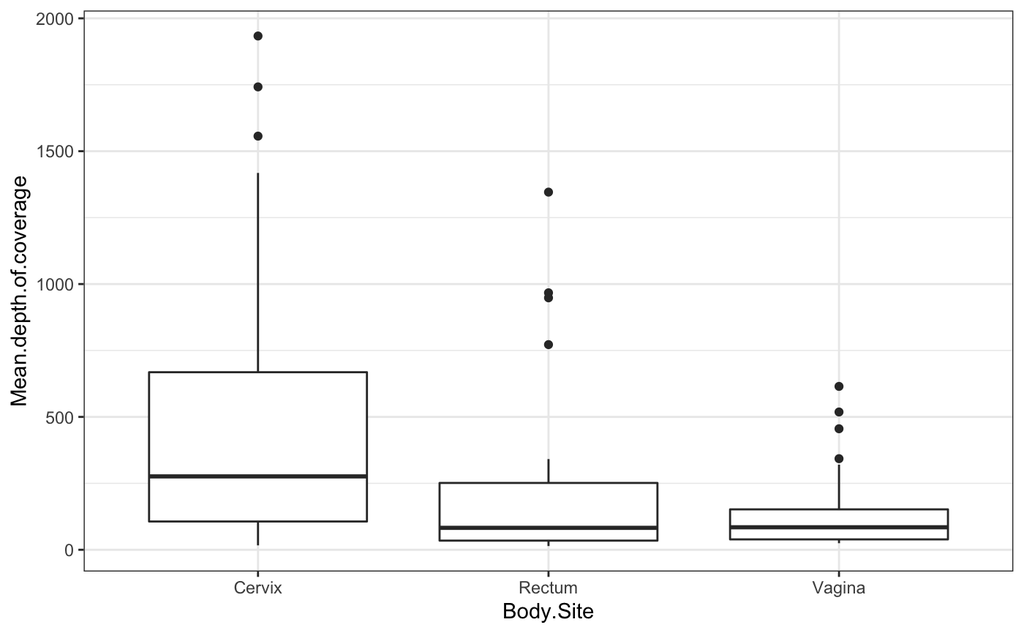

```r
#Figure W3
ggplot(mean_doc,aes(x=Body.Site,y=Mean.depth.of.coverage)) +
  geom_boxplot() +
  theme_bw()
```

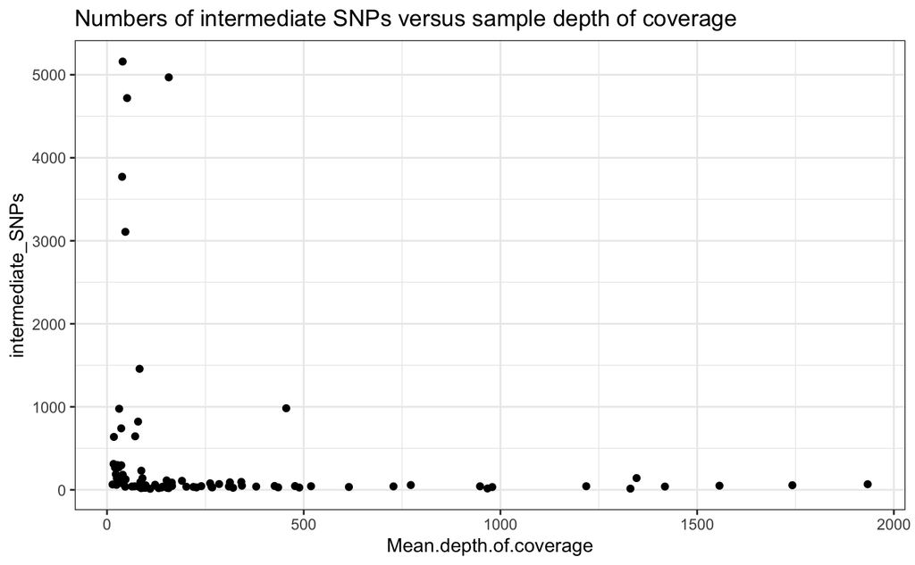

```r
ggplot(mean_doc,aes(x=Mean.depth.of.coverage,y=intermediate_SNPs)) +
  geom_point()+
  theme_bw() +
  ggtitle("Numbers of intermediate SNPs versus sample depth of coverage")
```

```r
RI_SNPs <- res_table %>%
  select(subject_name,RonlyRI,ConlyRI,VonlyRI) %>%
  gather("site","SNPs",-subject_name) %>%
  mutate(Sample = case_when(site == "RonlyRI" ~ paste0(subject_name,"R"),
                                site == "ConlyRI" ~ paste0(subject_name,"C"),
                                site == "VonlyRI" ~ paste0(subject_name,"V")
                                )) %>%
  inner_join(.,mean_doc, by = "Sample")
```

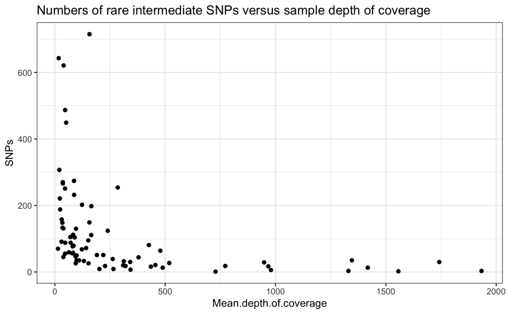

```r
ggplot(RI_SNPs,aes(x=Mean.depth.of.coverage,y=SNPs)) +
  geom_point()+
  theme_bw() +
  ggtitle("Numbers of rare intermediate SNPs versus sample depth of coverage")
```

```r
RI_SNPs %>% filter(Mean.depth.of.coverage > 1000) %>%
  filter(SNPs > 0)
```

| subject_name | site | SNPs | Sample | Subject | Body.Site | Mean.depth.of.coverage | intermediate_SNPs |
| --- | --- | --- | --- | --- | --- | --- | --- |
| 951 | RonlyRI | 35 | 951R | 951 | Rectum | 1345.959 | 142 |
| 1106 | ConlyRI | 3 | 1106C | 1106 | Cervix | 1330.369 | 15 |
| 519 | ConlyRI | 3 | 519C | 519 | Cervix | 1933.492 | 68 |
| 72 | ConlyRI | 13 | 72C | 72 | Cervix | 1418.151 | 40 |
| 968 | ConlyRI | 2 | 968C | 968 | Cervix | 1556.688 | 50 |
| 98 | ConlyRI | 30 | 98C | 98 | Cervix | 1742.018 | 56 |

```r
F_SNPs <- res_table %>%
  select(subject_name,RonlyF,ConlyF,VonlyF) %>%
  gather("site","SNPs",-subject_name) %>%
  mutate(Sample = case_when(site == "RonlyF" ~ paste0(subject_name,"R"),
                                site == "ConlyF" ~ paste0(subject_name,"C"),
                                site == "VonlyF" ~ paste0(subject_name,"V")
                                )) %>%
  inner_join(.,mean_doc, by = "Sample")
```

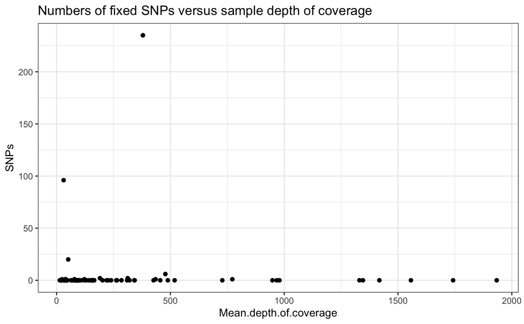

```r
ggplot(F_SNPs,aes(x=Mean.depth.of.coverage,y=SNPs)) +
  geom_point()+
  theme_bw() +
  ggtitle("Numbers of fixed SNPs versus sample depth of coverage")
```

```r
Supplemental_Table_3 <- read.delim("~/GitHub/Ct_MAP_analysis/Supplemental_Table_3-2022-06-12.tsv") %>%
  select(c(1:5))
Supp_Table_3_res <- inner_join(Supplemental_Table_3,res_table, by = c("Participant"="subject_name"))
write_tsv(Supp_Table_3_res, file = "new_supplementary_table3.tsv")
```

Venn Diagram 1

```r
venn_tab1 <- Supp_Table_3_res %>%
  filter(Group == "A") %>%
  select(Participant,RonlyFrare,ConlyFrare,VonlyFrare,RConlyFrare,VConlyFrare,RVonlyFrare) %>%
  mutate(RonlyFrare = ifelse(RonlyFrare > 0,paste0(Participant,"R",RonlyFrare),"")) %>%
  mutate(VonlyFrare = ifelse(VonlyFrare > 0,paste0(Participant,"V",VonlyFrare),"")) %>%
  mutate(ConlyFrare = ifelse(ConlyFrare > 0,paste0(Participant,"C",ConlyFrare),"")) %>%
  mutate(RConlyFrare = ifelse(RConlyFrare > 0,paste0(Participant,"RC",RConlyFrare),"")) %>%
  mutate(VConlyFrare = ifelse(VConlyFrare > 0,paste0(Participant,"VC",VConlyFrare),"")) %>%
  mutate(RVonlyFrare = ifelse(RVonlyFrare > 0,paste0(Participant,"RV",RVonlyFrare),""))
fixed_mutations <- as.vector(as.matrix(venn_tab1[,c("RonlyFrare","ConlyFrare","VonlyFrare","RConlyFrare","VConlyFrare","RVonlyFrare")]))
fixed_mutations <- fixed_mutations[fixed_mutations != ""]

C_strains <- c(str_which(fixed_mutations,"C"),venn_tab1$Participant)
R_strains <- c(str_which(fixed_mutations,"R"),venn_tab1$Participant)
V_strains <- c(str_which(fixed_mutations,"V"),venn_tab1$Participant)

library(VennDiagram)
library(RColorBrewer)
myCol <- brewer.pal(3,"Accent")
venn.diagram(
        x = list(C_strains, R_strains, V_strains),
        category.names = c("Endocervix" , "Rectum " , "Vagina"),
        filename = 'VennFig1.png',
        output=TRUE,

        # Output features
        imagetype="png" ,
        height = 480 ,
        width = 480 ,
        resolution = 300,
        compression = "lzw",

        # Circles
        lwd = 2,
        lty = 'blank',
        fill = myCol,

        # Numbers
        cex = .6,
        fontface = "bold",
        fontfamily = "sans",

        # Set names
        cat.cex = 0.6,
        cat.fontface = "bold",
        cat.default.pos = "outer",
        cat.pos = c(-27, 27, 135),
        cat.dist = c(0.055, 0.055, 0.085),
        cat.fontfamily = "sans",
        rotation = 1
)
```

```
[1] 1
```

Venn diagram 2

```r
venn_tab2 <- Supp_Table_3_res %>%
  filter(Group == "A") %>%
  select(Participant,RonlyFrare,ConlyFrare,VonlyFrare,RConlyFrare,VConlyFrare,RVonlyFrare,RonlyF_VIrare,RonlyF_CIrare,ConlyF_RIrare,ConlyF_VIrare,VonlyF_RIrare,VonlyF_CIrare) %>%
  mutate(RonlyFrare = ifelse(RonlyFrare > 0,paste0(Participant,"R",RonlyFrare),"")) %>%
  mutate(VonlyFrare = ifelse(VonlyFrare > 0,paste0(Participant,"V",VonlyFrare),"")) %>%
  mutate(ConlyFrare = ifelse(ConlyFrare > 0,paste0(Participant,"C",ConlyFrare),"")) %>%
  mutate(RConlyFrare = ifelse(RConlyFrare > 0,paste0(Participant,"RC",RConlyFrare),"")) %>%
  mutate(VConlyFrare = ifelse(VConlyFrare > 0,paste0(Participant,"VC",VConlyFrare),"")) %>%
  mutate(RVonlyFrare = ifelse(RVonlyFrare > 0,paste0(Participant,"RV",RVonlyFrare),"")) %>%
  mutate(RonlyF_VIrare = ifelse(RonlyF_VIrare > 0,paste0(Participant,"RVI",RonlyF_VIrare),"")) %>%
  mutate(RonlyF_CIrare = ifelse(RonlyF_CIrare > 0,paste0(Participant,"RCI",RonlyF_CIrare),"")) %>%
  mutate(ConlyF_VIrare = ifelse(ConlyF_VIrare > 0,paste0(Participant,"CVI",ConlyF_VIrare),"")) %>%
  mutate(ConlyF_RIrare = ifelse(ConlyF_RIrare > 0,paste0(Participant,"CRI",ConlyF_RIrare),"")) %>%
  mutate(VonlyF_CIrare = ifelse(VonlyF_CIrare > 0,paste0(Participant,"VCI",VonlyF_CIrare),"")) %>%
  mutate(VonlyF_RIrare = ifelse(VonlyF_RIrare > 0,paste0(Participant,"VRI",VonlyF_RIrare),""))

fixed_mutations2 <- as.vector(as.matrix(venn_tab2[,c("RonlyFrare","ConlyFrare","VonlyFrare","RConlyFrare","VConlyFrare","RVonlyFrare","RonlyF_VIrare","RonlyF_CIrare","ConlyF_RIrare","ConlyF_VIrare","VonlyF_RIrare","VonlyF_CIrare")]))
fixed_mutations2 <- fixed_mutations2[fixed_mutations2 != ""]

C_strains2 <- c(str_which(fixed_mutations2,"C"),venn_tab2$Participant)
R_strains2 <- c(str_which(fixed_mutations2,"R"),venn_tab2$Participant)
V_strains2 <- c(str_which(fixed_mutations2,"V"),venn_tab2$Participant)
```

```r
library(VennDiagram)
library(RColorBrewer)
myCol <- brewer.pal(3,"Accent")
venn.diagram(
        x = list(C_strains2, R_strains2, V_strains2),
        category.names = c("Endocervix" , "Rectum " , "Vagina"),
        filename = 'VennFig2.png',
        output=TRUE,

        # Output features
        imagetype="png" ,
        height = 480 ,
        width = 480 ,
        resolution = 300,
        compression = "lzw",

        # Circles
        lwd = 2,
        lty = 'blank',
        fill = myCol,

        # Numbers
        cex = .4,
        fontface = "bold",
        fontfamily = "sans",

        # Set names
        cat.cex = 0.4,
        cat.fontface = "bold",
        cat.default.pos = "text",
        cat.pos = c(-27, 27, 135),
        cat.dist = c(0.055, 0.055, 0.085),
        cat.fontfamily = "sans",
        rotation = 1
)
```

```
[1] 1
```

# stats used in the paper

```r
gpA_rectal_fixed <- Supp_Table_3_res %>%
  filter(Group == "A") %>%
  filter(RonlyF > 0) %>%
  nrow()
gpA_vaginal_fixed <- Supp_Table_3_res %>%
  filter(Group == "A") %>%
  filter(VonlyF > 0) %>%
  nrow()
gpA_endocervical_fixed <- Supp_Table_3_res %>%
  filter(Group == "A") %>%
  filter(ConlyF > 0) %>%
  nrow()
gpA_RC_fixed <- Supp_Table_3_res %>%
  filter(Group == "A") %>%
  filter(RConlyF > 0) %>%
  nrow()
gpA_RV_fixed <- Supp_Table_3_res %>%
  filter(Group == "A") %>%
  filter(RVonlyF > 0) %>%
  nrow()
gpA_VC_fixed <- Supp_Table_3_res %>%
  filter(Group == "A") %>%
  filter(VConlyF > 0) %>%
  nrow()
gpA_RC_rareI <- Supp_Table_3_res %>%
  filter(Group == "A") %>%
  filter(RConlyRIrare > 0) %>%
  nrow()
gpA_RV_rareI <- Supp_Table_3_res %>%
  filter(Group == "A") %>%
  filter(RVonlyRIrare > 0) %>%
  nrow()
gpA_VC_rareI <- Supp_Table_3_res %>%
  filter(Group == "A") %>%
  filter(VConlyRIrare > 0) %>%
  nrow()

gpA_R_fixed_rareC <- Supp_Table_3_res %>%
  filter(Group == "A") %>%
  filter(RonlyF_CIrare > 0 | RonlyF_CandVIrare > 0) %>%
  nrow()
gpA_R_fixed_rareV <- Supp_Table_3_res %>%
  filter(Group == "A") %>%
  filter(RonlyF_VIrare > 0 | RonlyF_CandVIrare > 0) %>%
  nrow()

gpA_C_fixed_rareR <- Supp_Table_3_res %>%
  filter(Group == "A") %>%
  filter(ConlyF_RIrare > 0 | ConlyF_RandVIrare > 0) %>%
  nrow()
gpA_C_fixed_rareV <- Supp_Table_3_res %>%
  filter(Group == "A") %>%
  filter(ConlyF_VIrare > 0 | ConlyF_RandVIrare > 0) %>%
  nrow()

gpA_V_fixed_rareR <- Supp_Table_3_res %>%
  filter(Group == "A") %>%
  filter(VonlyF_RIrare > 0 | VonlyF_CandRIrare > 0) %>%
  nrow()
gpA_V_fixed_rareC <- Supp_Table_3_res %>%
  filter(Group == "A") %>%
  filter(VonlyF_CIrare > 0 | VonlyF_CandRIrare > 0) %>%
  nrow()
```

“Only 1 Group A participants had fixed SNP in both rectal and endocervix”

“Only 1 Group A participants had fixed SNP in both rectal and vagina”

“Only 0 Group A participants had fixed SNP in both endocervix and vagina”

“Only 18 Group A participants had rare intermediate SNVs in both rectum and endocervix”

“Only 17 Group A participants had rare intermediate SNVs in both rectum and vagina”

“Only 18 Group A participants had rare intermediate SNVs in both vagina and endocervix”

“Table 2. 7 Rectal fixed SNP, rare SNV in endocervix”

“Table 2. 7 Rectal fixed SNP, rare SNV in vagina”

“Table 2. 8 Endocervix fixed SNP, rare SNV in rectum”

“Table 2. 9 Endocervix fixed SNP, rare SNV in vagina”

“Table 2. 11 Vagina fixed SNP, rare SNV in rectum”

“Table 2. 11 Vagina fixed SNP, rare SNV in endocervix”